# R Notebook

```r
# load packages
library(mlbench)
library(caret)
library(corrplot)
# attach the BostonHousing dataset
data(BostonHousing)
```

```r
# Split out validation dataset
# create a list of 80% of the rows in the original dataset we can use for training
set.seed(7)
validationIndex <- createDataPartition(BostonHousing$medv, p=0.80, list=FALSE)
# select 20% of the data for validation
validation <- BostonHousing[-validationIndex,]
# use the remaining 80% of data to training and testing the models
dataset <- BostonHousing[validationIndex,]
```

```r
# dimensions of dataset
dim(dataset)
```

```
[1] 407  14
```

```r
# list types for each attribute
sapply(dataset, class)
```

```
     crim        zn     indus      chas
"numeric" "numeric" "numeric"  "factor"
      nox        rm       age       dis
"numeric" "numeric" "numeric" "numeric"
      rad       tax   ptratio         b
"numeric" "numeric" "numeric" "numeric"
    lstat      medv
"numeric" "numeric"
```

```r
# take a peek at the first 5 rows of the data
head(dataset, n=20)
```

|  | crim | zn | indus | chas | nox | rm | age | dis | rad | tax | ptratio | b | lstat | medv |
| --- | --- | --- | --- | --- | --- | --- | --- | --- | --- | --- | --- | --- | --- | --- |
| 1 | 0.00632 | 18.0 | 2.31 | 0 | 0.538 | 6.575 | 65.2 | 4.0900 | 1 | 296 | 15.3 | 396.90 | 4.98 | 24.0 |
| 2 | 0.02731 | 0.0 | 7.07 | 0 | 0.469 | 6.421 | 78.9 | 4.9671 | 2 | 242 | 17.8 | 396.90 | 9.14 | 21.6 |
| 3 | 0.02729 | 0.0 | 7.07 | 0 | 0.469 | 7.185 | 61.1 | 4.9671 | 2 | 242 | 17.8 | 392.83 | 4.03 | 34.7 |
| 4 | 0.03237 | 0.0 | 2.18 | 0 | 0.458 | 6.998 | 45.8 | 6.0622 | 3 | 222 | 18.7 | 394.63 | 2.94 | 33.4 |
| 5 | 0.06905 | 0.0 | 2.18 | 0 | 0.458 | 7.147 | 54.2 | 6.0622 | 3 | 222 | 18.7 | 396.90 | 5.33 | 36.2 |
| 6 | 0.02985 | 0.0 | 2.18 | 0 | 0.458 | 6.430 | 58.7 | 6.0622 | 3 | 222 | 18.7 | 394.12 | 5.21 | 28.7 |
| 7 | 0.08829 | 12.5 | 7.87 | 0 | 0.524 | 6.012 | 66.6 | 5.5605 | 5 | 311 | 15.2 | 395.60 | 12.43 | 22.9 |
| 10 | 0.17004 | 12.5 | 7.87 | 0 | 0.524 | 6.004 | 85.9 | 6.5921 | 5 | 311 | 15.2 | 386.71 | 17.10 | 18.9 |
| 11 | 0.22489 | 12.5 | 7.87 | 0 | 0.524 | 6.377 | 94.3 | 6.3467 | 5 | 311 | 15.2 | 392.52 | 20.45 | 15.0 |
| 12 | 0.11747 | 12.5 | 7.87 | 0 | 0.524 | 6.009 | 82.9 | 6.2267 | 5 | 311 | 15.2 | 396.90 | 13.27 | 18.9 |

[output cut: 10 more lines]

```r
# summarize attribute distributions
summary(dataset)
```

```
      crim                zn
 Min.   : 0.00632   Min.   :  0.00
 1st Qu.: 0.07964   1st Qu.:  0.00
 Median : 0.26838   Median :  0.00
 Mean   : 3.63725   Mean   : 11.92
 3rd Qu.: 3.68567   3rd Qu.: 15.00
 Max.   :88.97620   Max.   :100.00
     indus       chas         nox
 Min.   : 0.74   0:378   Min.   :0.3850
 1st Qu.: 4.93   1: 29   1st Qu.:0.4480
 Median : 8.56           Median :0.5380
 Mean   :11.00           Mean   :0.5547
 3rd Qu.:18.10           3rd Qu.:0.6310
 Max.   :27.74           Max.   :0.8710
       rm             age
 Min.   :3.561   Min.   :  6.20
 1st Qu.:5.888   1st Qu.: 42.70
 Median :6.212   Median : 77.30
 Mean   :6.290   Mean   : 68.38
 3rd Qu.:6.619   3rd Qu.: 94.20
 Max.   :8.780   Max.   :100.00
      dis              rad
 Min.   : 1.130   Min.   : 1.000
 1st Qu.: 2.109   1st Qu.: 4.000
 Median : 3.152   Median : 5.000
 Mean   : 3.818   Mean   : 9.595
 3rd Qu.: 5.215   3rd Qu.:24.000
 Max.   :12.127   Max.   :24.000
      tax           ptratio
 Min.   :187.0   Min.   :12.60
 1st Qu.:280.5   1st Qu.:17.00
 Median :334.0   Median :19.00
 Mean   :408.7   Mean   :18.42
 3rd Qu.:666.0   3rd Qu.:20.20
 Max.   :711.0   Max.   :22.00
       b              lstat
 Min.   :  0.32   Min.   : 1.920
 1st Qu.:373.81   1st Qu.: 7.065
 Median :391.27   Median :11.320
 Mean   :357.19   Mean   :12.556
 3rd Qu.:396.02   3rd Qu.:16.455
 Max.   :396.90   Max.   :37.970
      medv
 Min.   : 5.00
 1st Qu.:17.05
 Median :21.20
 Mean   :22.52
 3rd Qu.:25.00
 Max.   :50.00
```

```r
#Let's go ahead and convert chas to a numeric attribute.
dataset[,4] <- as.numeric(as.character(dataset[,4]))
```

```r
cor(dataset[,1:13])
```

```
               crim          zn      indus
crim     1.00000000 -0.19958871  0.4075617
zn      -0.19958871  1.00000000 -0.5314446
indus    0.40756169 -0.53144458  1.0000000
chas    -0.05507162 -0.02986909  0.0658346
nox      0.40994989 -0.52021705  0.7732538
rm      -0.19398049  0.31106841 -0.3826220
age      0.35240196 -0.58447039  0.6511547
dis     -0.37564969  0.67986750 -0.7113431
rad      0.60834345 -0.32273403  0.6199844
tax      0.57112501 -0.31839453  0.7185102
ptratio  0.28970459 -0.38877931  0.3781852
b       -0.34424053  0.17471792 -0.3643714
lstat    0.42294190 -0.42188931  0.6135914
                chas        nox         rm
crim    -0.055071619  0.4099499 -0.1939805
zn      -0.029869089 -0.5202171  0.3110684
indus    0.065834605  0.7732538 -0.3826220
chas     1.000000000  0.0933997  0.1267673
nox      0.093399699  1.0000000 -0.2960506
rm       0.126767331 -0.2960506  1.0000000
age      0.073501472  0.7338299 -0.2261571
dis     -0.099046145 -0.7693426  0.2074524
rad     -0.002445292  0.6276047 -0.2212616
tax     -0.030644325  0.6757625 -0.2952685
ptratio -0.122831776  0.1887657 -0.3648317
b        0.037822587 -0.3683865  0.1259942
lstat   -0.084304578  0.5838934 -0.6119520
                age         dis          rad
crim     0.35240196 -0.37564969  0.608343448
zn      -0.58447039  0.67986750 -0.322734034
indus    0.65115470 -0.71134308  0.619984390
chas     0.07350147 -0.09904614 -0.002445292
nox      0.73382994 -0.76934256  0.627604694
rm      -0.22615708  0.20745239 -0.221261630
age      1.00000000 -0.74924225  0.468963375
dis     -0.74924225  1.00000000 -0.503720701
rad      0.46896338 -0.50372070  1.000000000
tax      0.50581099 -0.52641543  0.920053202
ptratio  0.27092980 -0.22794289  0.479714803
```

[output cut: 15 more lines]

```
lstat    0.55382142  0.4092786 -0.35088088
              lstat
crim     0.42294190
zn      -0.42188931
indus    0.61359140
chas    -0.08430458
nox      0.58389344
rm      -0.61195203
age      0.60664241
dis     -0.50129941
rad      0.50251178
tax      0.55382142
ptratio  0.40927864
b       -0.35088088
lstat    1.00000000
```

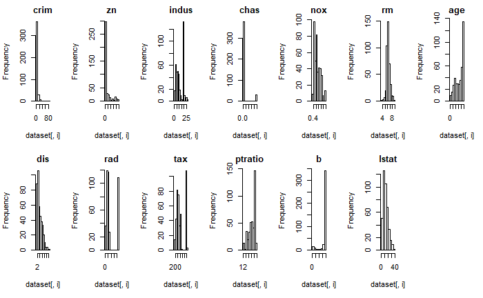

```r
# histograms each attribute
par(mfrow=c(2,7))
for(i in 1:13) {
hist(dataset[,i], main=names(dataset)[i])
}
```

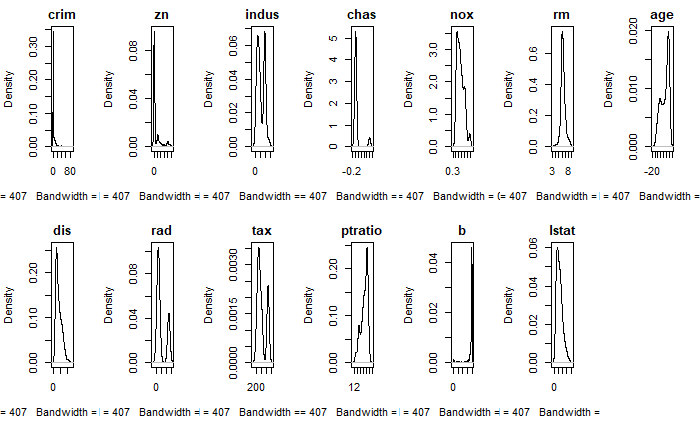

```r
# density plot for each attribute
par(mfrow=c(2,7))
for(i in 1:13) {
plot(density(dataset[,i]), main=names(dataset)[i])
}
```

This perhaps adds more evidence to our suspicion about possible exponential and bimodal distributions. It also looks like nox, rm and lsat may be skewed Gaussian distributions, which might be helpful later with transforms.

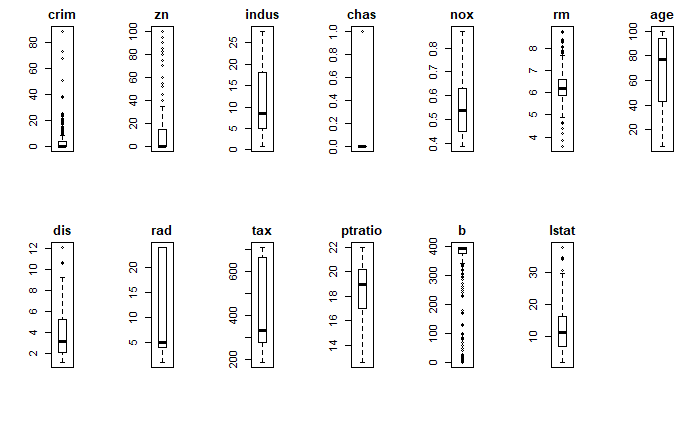

```r
# boxplots for each attribute
par(mfrow=c(2,7))
for(i in 1:13) {
boxplot(dataset[,i], main=names(dataset)[i])}
```

This helps point out the skew in many distributions so much so that data looks like outliers (e.g. beyond the whisker of the plots).

# Multi modal Data Visualizations

```r
# scatterplot matrix
pairs(dataset[,1:13])
```

```
Error in plot.new() : figure margins too large
```

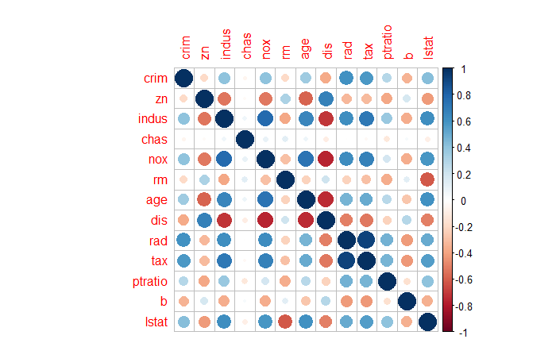

```r
# correlation plot
correlations <- cor(dataset[,1:13])
corrplot(correlations, method="circle")
```

There is a lot of structure in this dataset. We need to think about transforms that we could use later to better expose the structure which in turn may improve modeling accuracy. So far it would be worth trying:  Feature selection and removing the most correlated attributes.  Normalizing the dataset to reduce the e ect of di ering scales.  Standardizing the dataset to reduce the e ects of di ering distributions.  Box-Cox transform to see if attening out some of the distributions improves accuracy.

#Evaluate Algorithms:Baseline

```r
# Run algorithms using 10-fold cross validation
trainControl <- trainControl(method="repeatedcv", number=10, repeats=3)
metric <- "RMSE"
```

```r
# LM
set.seed(7)
fit.lm <- train(medv~., data=dataset, method="lm", metric=metric, preProc=c("center",
"scale"), trControl=trainControl)
# GLM
set.seed(7)
fit.glm <- train(medv~., data=dataset, method="glm", metric=metric, preProc=c("center",
"scale"), trControl=trainControl)
# GLMNET
set.seed(7)
fit.glmnet <- train(medv~., data=dataset, method="glmnet", metric=metric,
preProc=c("center", "scale"), trControl=trainControl)
# SVM
set.seed(7)
fit.svm <- train(medv~., data=dataset, method="svmRadial", metric=metric,
preProc=c("center", "scale"), trControl=trainControl)
# CART
set.seed(7)
grid <- expand.grid(.cp=c(0, 0.05, 0.1))
fit.cart <- train(medv~., data=dataset, method="rpart", metric=metric, tuneGrid=grid,
preProc=c("center", "scale"), trControl=trainControl)
# KNN
set.seed(7)
fit.knn <- train(medv~., data=dataset, method="knn", metric=metric, preProc=c("center",
"scale"), trControl=trainControl)
```

Let’s compare the algorithms. We will use a simple table of results to get a quick idea of what is going on. We will also use a dot plot to show the 95% con dence level for the estimated metrics.

```r
# Compare algorithms
results <- resamples(list(LM=fit.lm, GLM=fit.glm, GLMNET=fit.glmnet, SVM=fit.svm,
CART=fit.cart, KNN=fit.knn))
summary(results)
```

```
Call:
summary.resamples(object = results)

Models: LM, GLM, GLMNET, SVM, CART, KNN
Number of resamples: 30

MAE
           Min.  1st Qu.   Median     Mean  3rd Qu.     Max. NA's
LM     2.296870 2.897637 3.368197 3.315490 3.701331 4.644634    0
GLM    2.296870 2.897637 3.368197 3.315490 3.701331 4.644634    0
GLMNET 2.300353 2.883646 3.336121 3.304888 3.697932 4.625185    0
SVM    1.422339 1.992016 2.516175 2.387512 2.654770 3.345278    0
CART   2.216672 2.620729 2.883975 2.933934 3.081861 4.161930    0
KNN    1.978049 2.685764 2.866806 2.947500 3.237153 3.998333    0

RMSE
           Min.  1st Qu.   Median     Mean  3rd Qu.     Max. NA's
LM     2.991624 3.869651 4.632032 4.629323 5.317398 6.694651    0
GLM    2.991624 3.869651 4.632032 4.629323 5.317398 6.694651    0
GLMNET 2.990832 3.878814 4.615843 4.624746 5.316638 6.692580    0
SVM    2.049504 2.949764 3.814475 3.908810 4.455599 6.979067    0
CART   2.766558 3.379400 3.997915 4.199124 4.600681 7.087656    0
KNN    2.653686 3.741499 4.415526 4.482558 5.064124 6.976913    0

Rsquared
            Min.   1st Qu.    Median      Mean   3rd Qu.      Max. NA's
LM     0.5050763 0.6744319 0.7474419 0.7404282 0.8127596 0.8999946    0
GLM    0.5050763 0.6744319 0.7474419 0.7404282 0.8127596 0.8999946    0
GLMNET 0.5033006 0.6730052 0.7474746 0.7410698 0.8155090 0.9039292    0
SVM    0.5193410 0.7623629 0.8447057 0.8103278 0.8958487 0.9700852    0
CART   0.5144771 0.7367598 0.8156225 0.7782237 0.8421169 0.8989506    0
KNN    0.5187652 0.7478699 0.8043069 0.7699680 0.8293089 0.9307667    0
```

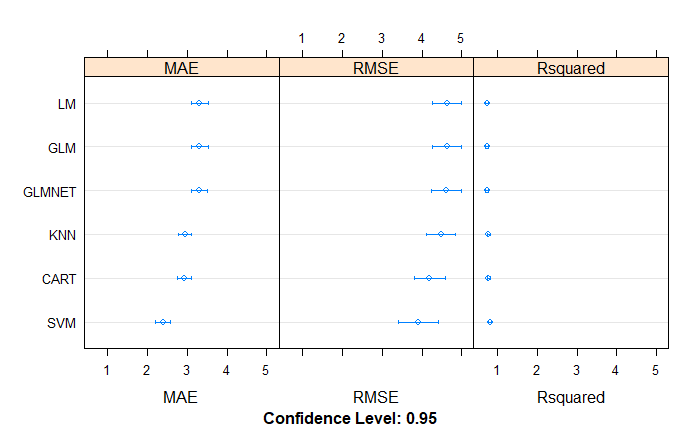

```r
dotplot(results)
```

It looks like SVM has the lowest RMSE, followed closely by the other non-linear algorithms CART and KNN. The linear regression algorithms all appear to be in the same ball park and slightly worse error. We can also see that SVM and the other non-linear algorithms have the best t for the data in their R2 measures.

Perhaps the worse performance of the linear regression algorithms has something to do with the highly correlated attributes. Let’s look at that.

# Evaluate Algorithms: Feature Selection

In this step we will remove the highly correlated attributes and see what e ect that has on the evaluation metrics. We can nd and remove the highly correlated attributes using the findCorrelation() function from the caret package as follows:

```r
# remove correlated attributes
# find attributes that are highly corrected
set.seed(7)
cutoff <- 0.70
correlations <- cor(dataset[,1:13])
highlyCorrelated <- findCorrelation(correlations, cutoff=cutoff)
for (value in highlyCorrelated) {
print(names(dataset)[value])
}
```

```
[1] "indus"
[1] "nox"
[1] "tax"
[1] "dis"
```

```r
# create a new dataset without highly corrected features
datasetFeatures <- dataset[,-highlyCorrelated]
dim(datasetFeatures)
```

```
[1] 407  10
```

We can see that we have dropped 4 attributes: indus, box, tax and dis. Now let’s try the same 6 algorithms from our base line experiment.

```r
# Run algorithms using 10-fold cross validation
trainControl <- trainControl(method="repeatedcv", number=10, repeats=3)
metric <- "RMSE"
# lm
set.seed(7)
fit.lm <- train(medv~., data=datasetFeatures, method="lm", metric=metric,
preProc=c("center", "scale"), trControl=trainControl)
# GLM
set.seed(7)
fit.glm <- train(medv~., data=datasetFeatures, method="glm", metric=metric,
preProc=c("center", "scale"), trControl=trainControl)
# GLMNET
set.seed(7)
fit.glmnet <- train(medv~., data=datasetFeatures, method="glmnet", metric=metric,
preProc=c("center", "scale"), trControl=trainControl)
# SVM
set.seed(7)
fit.svm <- train(medv~., data=datasetFeatures, method="svmRadial", metric=metric,
preProc=c("center", "scale"), trControl=trainControl)
# CART
set.seed(7)
grid <- expand.grid(.cp=c(0, 0.05, 0.1))
fit.cart <- train(medv~., data=datasetFeatures, method="rpart", metric=metric,
tuneGrid=grid, preProc=c("center", "scale"), trControl=trainControl)
# KNN
set.seed(7)
fit.knn <- train(medv~., data=datasetFeatures, method="knn", metric=metric,
preProc=c("center", "scale"), trControl=trainControl)
# Compare algorithms
feature_results <- resamples(list(LM=fit.lm, GLM=fit.glm, GLMNET=fit.glmnet, SVM=fit.svm,
CART=fit.cart, KNN=fit.knn))

summary(feature_results)
```

```
Call:
summary.resamples(object = feature_results)

Models: LM, GLM, GLMNET, SVM, CART, KNN
Number of resamples: 30

MAE
           Min.  1st Qu.   Median     Mean
LM     2.597582 3.198186 3.533505 3.529329
GLM    2.597582 3.198186 3.533505 3.529329
GLMNET 2.628837 3.117948 3.542265 3.509583
SVM    1.870109 2.362839 2.734075 2.702778
CART   2.081461 2.680047 2.875717 2.979567
KNN    2.169500 2.603482 2.873902 2.919836
        3rd Qu.     Max. NA's
LM     3.810776 4.776058    0
GLM    3.810776 4.776058    0
GLMNET 3.868589 4.690752    0
SVM    2.963509 3.597276    0
CART   3.143345 4.103067    0
KNN    3.205521 3.720976    0

RMSE
           Min.  1st Qu.   Median     Mean
LM     3.385745 4.172629 4.913293 4.991283
GLM    3.385745 4.172629 4.913293 4.991283
GLMNET 3.382741 4.117021 4.962157 4.971174
SVM    2.506249 3.229388 4.119990 4.253566
CART   2.734757 3.571064 3.893022 4.267655
KNN    2.668598 3.530793 4.046128 4.343244
        3rd Qu.     Max. NA's
LM     5.767162 7.146177    0
GLM    5.767162 7.146177    0
GLMNET 5.726988 7.173045    0
SVM    4.983215 7.412917    0
CART   4.762564 7.431916    0
KNN    5.062585 7.029593    0

Rsquared
            Min.   1st Qu.    Median      Mean
LM     0.4215797 0.6389221 0.6803902 0.7039736
GLM    0.4215797 0.6389221 0.6803902 0.7039736
GLMNET 0.4167207 0.6546938 0.6911644 0.7077446
SVM    0.4694850 0.7139050 0.8125167 0.7732146
CART   0.4852551 0.7379702 0.7967859 0.7710499
KNN    0.4346147 0.6931495 0.7991336 0.7664082
         3rd Qu.      Max. NA's
LM     0.8000201 0.8996477    0
GLM    0.8000201 0.8996477    0
GLMNET 0.8071089 0.9051059    0
SVM    0.8608406 0.9460838    0
CART   0.8474429 0.9176368    0
KNN    0.8450951 0.9301857    0
```

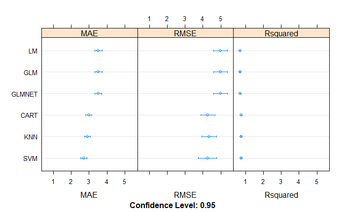

```r
dotplot(feature_results)
```

#Evaluate Algorithms: Box-Cox Transform

We know that some of the attributes have a skew and others perhaps have an exponential distribution.Let’s try using this transform to rescale the original data and evaluate the e ect on the same 6 algorithms. We will also leave in the centering and scaling for the bene t of the instance based method.

```r
# Run algorithms using 10-fold cross validation
trainControl <- trainControl(method="repeatedcv", number=10, repeats=3)
metric <- "RMSE"
# lm
set.seed(7)
fit.lm <- train(medv~., data=dataset, method="lm", metric=metric, preProc=c("center",
"scale", "BoxCox"), trControl=trainControl)
# GLM
set.seed(7)
fit.glm <- train(medv~., data=dataset, method="glm", metric=metric, preProc=c("center",
"scale", "BoxCox"), trControl=trainControl)
# GLMNET
set.seed(7)
fit.glmnet <- train(medv~., data=dataset, method="glmnet", metric=metric,
preProc=c("center", "scale", "BoxCox"), trControl=trainControl)
# SVM
set.seed(7)
fit.svm <- train(medv~., data=dataset, method="svmRadial", metric=metric,
preProc=c("center", "scale", "BoxCox"), trControl=trainControl)
# CART
set.seed(7)
grid <- expand.grid(.cp=c(0, 0.05, 0.1))
fit.cart <- train(medv~., data=dataset, method="rpart", metric=metric, tuneGrid=grid,
preProc=c("center", "scale", "BoxCox"), trControl=trainControl)
# KNN
set.seed(7)
fit.knn <- train(medv~., data=dataset, method="knn", metric=metric, preProc=c("center",
"scale", "BoxCox"), trControl=trainControl)
# Compare algorithms
transformResults <- resamples(list(LM=fit.lm, GLM=fit.glm, GLMNET=fit.glmnet, SVM=fit.svm,
CART=fit.cart, KNN=fit.knn))

summary(transformResults)
```

```
Call:
summary.resamples(object = transformResults)

Models: LM, GLM, GLMNET, SVM, CART, KNN
Number of resamples: 30

MAE
           Min.  1st Qu.   Median     Mean  3rd Qu.     Max. NA's
LM     2.104233 2.797637 3.207088 3.175320 3.454257 4.435940    0
GLM    2.104233 2.797637 3.207088 3.175320 3.454257 4.435940    0
GLMNET 2.114563 2.798935 3.209521 3.169094 3.448723 4.432529    0
SVM    1.295913 1.953074 2.248200 2.259221 2.477442 3.189012    0
CART   2.216672 2.620729 2.891569 2.939787 3.106475 4.161930    0
KNN    2.328184 2.664636 2.818222 2.972252 3.271885 3.955278    0

RMSE
           Min.  1st Qu.   Median     Mean  3rd Qu.     Max. NA's
LM     2.819687 3.811635 4.431132 4.365406 4.995457 6.163792    0
GLM    2.819687 3.811635 4.431132 4.365406 4.995457 6.163792    0
GLMNET 2.831297 3.791174 4.421466 4.364087 5.000829 6.184862    0
SVM    1.804804 2.727022 3.413761 3.702897 4.235294 6.732293    0
CART   2.766558 3.379400 3.997915 4.234486 4.834258 7.087656    0
KNN    3.010540 3.725322 4.371531 4.515830 5.022143 7.297372    0

Rsquared
            Min.   1st Qu.    Median      Mean   3rd Qu.      Max. NA's
LM     0.5598749 0.7120390 0.7753579 0.7661885 0.8254844 0.9096007    0
GLM    0.5598749 0.7120390 0.7753579 0.7661885 0.8254844 0.9096007    0
GLMNET 0.5564608 0.7134025 0.7748693 0.7663531 0.8264084 0.9097210    0
SVM    0.5239104 0.7783632 0.8540991 0.8274159 0.9074418 0.9786169    0
CART   0.5144771 0.7273216 0.8156225 0.7743938 0.8430400 0.8989506    0
KNN    0.4922397 0.7231826 0.7919972 0.7622184 0.8419261 0.9365145    0
```

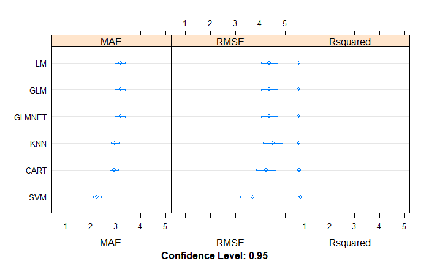

```r
dotplot(transformResults)
```

#Ensemble Methods

We can try some ensemble methods on the problem and see if we can get a further decrease in our RMSE. In this section we will look at some boosting and bagging techniques for decision trees.

```r
# try ensembles
trainControl <- trainControl(method="repeatedcv", number=10, repeats=3)
metric <- "RMSE"

# Random Forest
set.seed(7)
fit.rf <- train(medv~., data=dataset, method="rf", metric=metric, preProc=c("BoxCox"),
trControl=trainControl)
# Stochastic Gradient Boosting
set.seed(7)
fit.gbm <- train(medv~., data=dataset, method="gbm", metric=metric, preProc=c("BoxCox"),
trControl=trainControl, verbose=FALSE)

# Compare algorithms
ensembleResults <- resamples(list(RF=fit.rf, GBM=fit.gbm))
summary(ensembleResults)
```

```
Call:
summary.resamples(object = ensembleResults)

Models: RF, GBM
Number of resamples: 30

MAE
        Min.  1st Qu.   Median     Mean  3rd Qu.     Max. NA's
RF  1.636635 1.977145 2.200994 2.210221 2.302417 3.220658    0
GBM 1.646824 1.979192 2.265152 2.327776 2.545692 3.752348    0

RMSE
        Min.  1st Qu.   Median     Mean  3rd Qu.     Max. NA's
RF  2.112991 2.575385 3.076901 3.218102 3.695468 6.521859    0
GBM 1.917678 2.544770 3.310917 3.379109 3.665515 6.851109    0

Rsquared
         Min.   1st Qu.    Median      Mean   3rd Qu.      Max. NA's
RF  0.5972355 0.8517322 0.9004050 0.8685981 0.9188907 0.9724223    0
GBM 0.5581867 0.8154935 0.8886156 0.8508565 0.9120289 0.9643755    0
```

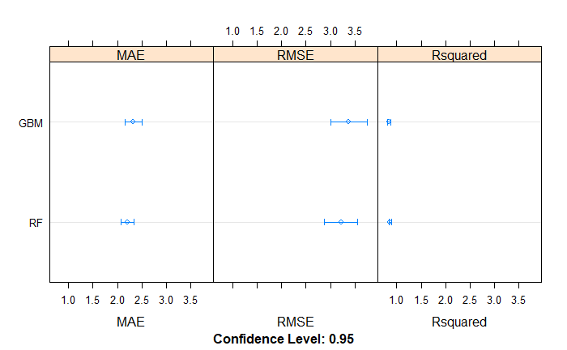

```r
dotplot(ensembleResults)
```

#Finalizing Results after Tuning

We can improve the accuracy of the well performing algorithms by tuning their parameters. In this section we will look at tuning the parameters of SVM with a Radial Basis Function (RBF). with more time it might be worth exploring tuning of the parameters for CART and KNN Let’s look at the default parameters already adopted.

```r
print(fit.svm)
```

```
Support Vector Machines with Radial Basis Function Kernel

407 samples
 13 predictor

Pre-processing: centered (13), scaled
 (13), Box-Cox transformation (11)
Resampling: Cross-Validated (10 fold, repeated 3 times)
Summary of sample sizes: 365, 366, 366, 367, 366, 366, ...
Resampling results across tuning parameters:

  C     RMSE      Rsquared   MAE
  0.25  4.540024  0.7717394  2.731571
  0.50  4.073572  0.8016482  2.459453
  1.00  3.702897  0.8274159  2.259221

Tuning parameter 'sigma' was held constant at
 a value of 0.1160954
RMSE was used to select the optimal model
 using the smallest value.
The final values used for the model were
 sigma = 0.1160954 and C = 1.
```

Let’s design a grid search around a C value of 1. We might see a small trend of decreasing RMSE with increasing C, so lets try all integer C values between 1 and 10. Another parameter that caret lets us tune is the sigma parameter. This is a smoothing parameter. Good sigma values are often start around 0.1, so we will try numbers before and after.

```r
# tune SVM sigma and C parametres
trainControl <- trainControl(method="repeatedcv", number=10, repeats=3)
metric <- "RMSE"
set.seed(7)
grid <- expand.grid(.sigma=c(0.025, 0.05, 0.1, 0.15), .C=seq(1, 10, by=1))
fit.svm <- train(medv~., data=dataset, method="svmRadial", metric=metric, tuneGrid=grid,
preProc=c("BoxCox"), trControl=trainControl)
print(fit.svm)
```

```
Support Vector Machines with Radial Basis Function Kernel

407 samples
 13 predictor

Pre-processing: Box-Cox transformation (11)
Resampling: Cross-Validated (10 fold, repeated 3 times)
Summary of sample sizes: 365, 366, 366, 367, 366, 366, ...
Resampling results across tuning parameters:

  sigma  C   RMSE      Rsquared   MAE
  0.025   1  3.666043  0.8304251  2.341464
  0.025   2  3.493628  0.8402429  2.210608
  0.025   3  3.448027  0.8424578  2.166475
  0.025   4  3.421134  0.8441250  2.144822
  0.025   5  3.406023  0.8452104  2.126361
  0.025   6  3.396596  0.8459419  2.118039
  0.025   7  3.392730  0.8458421  2.112808
  0.025   8  3.389535  0.8456315  2.109806
  0.025   9  3.381037  0.8459219  2.107856
  0.025  10  3.369434  0.8466299  2.103481
  0.050   1  3.610080  0.8333388  2.253360
  0.050   2  3.441528  0.8431029  2.172318
  0.050   3  3.360002  0.8478343  2.111491
  0.050   4  3.302564  0.8519628  2.081684
  0.050   5  3.245578  0.8563020  2.054521
  0.050   6  3.197392  0.8597917  2.032993
  0.050   7  3.162971  0.8623836  2.024649
  0.050   8  3.132003  0.8645481  2.016135
  0.050   9  3.111908  0.8658503  2.009976
  0.050  10  3.097578  0.8667604  2.006334
  0.100   1  3.682911  0.8286388  2.256098
  0.100   2  3.369351  0.8482277  2.120290
  0.100   3  3.231527  0.8577559  2.059342
  0.100   4  3.168919  0.8623427  2.043215
  0.100   5  3.137567  0.8645176  2.038875
  0.100   6  3.112662  0.8663073  2.037551
  0.100   7  3.094980  0.8675240  2.038389
  0.100   8  3.086051  0.8679036  2.039479
  0.100   9  3.080897  0.8682378  2.040387
  0.100  10  3.084181  0.8680824  2.045987
  0.150   1  3.785244  0.8219277  2.301245
  0.150   2  3.415474  0.8464298  2.141562
  0.150   3  3.296697  0.8543834  2.090340
  0.150   4  3.258625  0.8567102  2.088175
  0.150   5  3.236921  0.8575635  2.092287
  0.150   6  3.228499  0.8576468  2.102106
  0.150   7  3.228241  0.8573974  2.115081
  0.150   8  3.242664  0.8563191  2.133669
  0.150   9  3.260328  0.8550405  2.153824
  0.150  10  3.273906  0.8540664  2.170337

RMSE was used to select the optimal model
 using the smallest value.
The final values used for the model were
 sigma = 0.1 and C = 9.
```

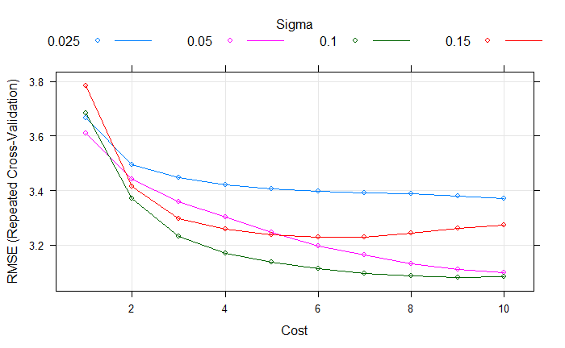

```r
plot(fit.svm)
```

We can see that the sigma values flatten out with larger C cost constraints. It looks like we might do well with a sigma of 0.1 and a C of 9. This gives us a respectable RMSE of 3.080897 and R^2 of 0.8682378